# P2

05 Mayo, 2023

## **Tema** : **Modelos de celulares más demandados en los estudiantes de la UTEC**

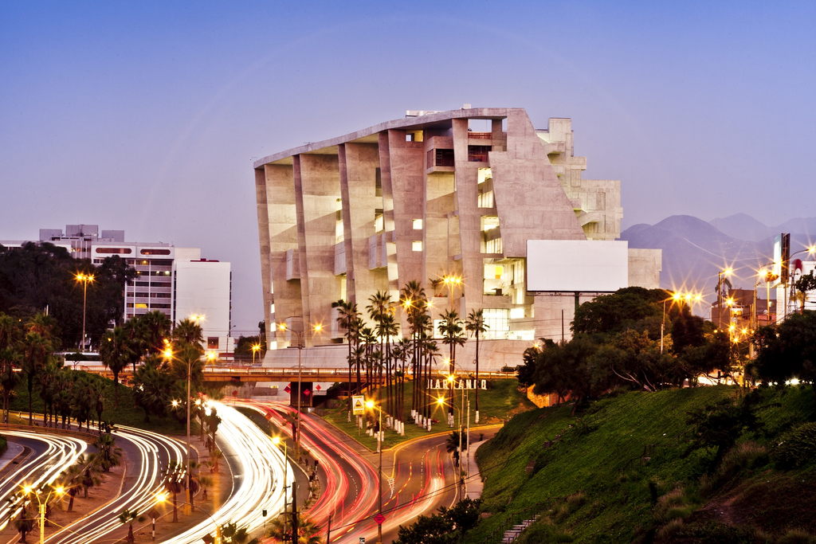

## **INTRODUCCIÓN**

**RELEVANCIA**

- Investigar y comprender las preferencias de cada estudiante de UTEC al momento de elegir un dispositivo móvil, conocer las diferentes características del dispositivo que lleven a su compra como: el precio, modelo, software, entre otros, que contiene cada dispositivo.

**a) OBJETIVO**: Identificar las características de los modelos de celulares que utilizan los estudiantes de UTEC, mediante un análisis estadístico para medir sus preferencias y satisfacción en relación con el celular.

- **Objetivos específicos:**
- Realizar una estimación de cuáles serían las condiciones ideales para medir la preferencia de los celulares de los estudiantes de UTEC.
- Utilizar descriptores estadísticos para determinar de manera precisa la relación entre variables.
- Comparar las diferencias en los comportamientos de las variables.

**b) JUSTIFICACIÓN**: El estudio aportará conclusiones importantes acerca de las preferencias en dispositivos móviles por los estudiantes de UTEC. Además, brindará una ayuda para aquellos alumnos que estén buscando renovar su celular, y puedan obtener las mejores características y/o precios que más se le adecue a su presupuesto.

**c)PLANIFICACIÓN**; Para la mostrar la planificación se creó un Diagrama de Gantt con las actividades realizadas. Primero se tuvo que instalar las librerías correspondientes para lograr dicho diagrama.

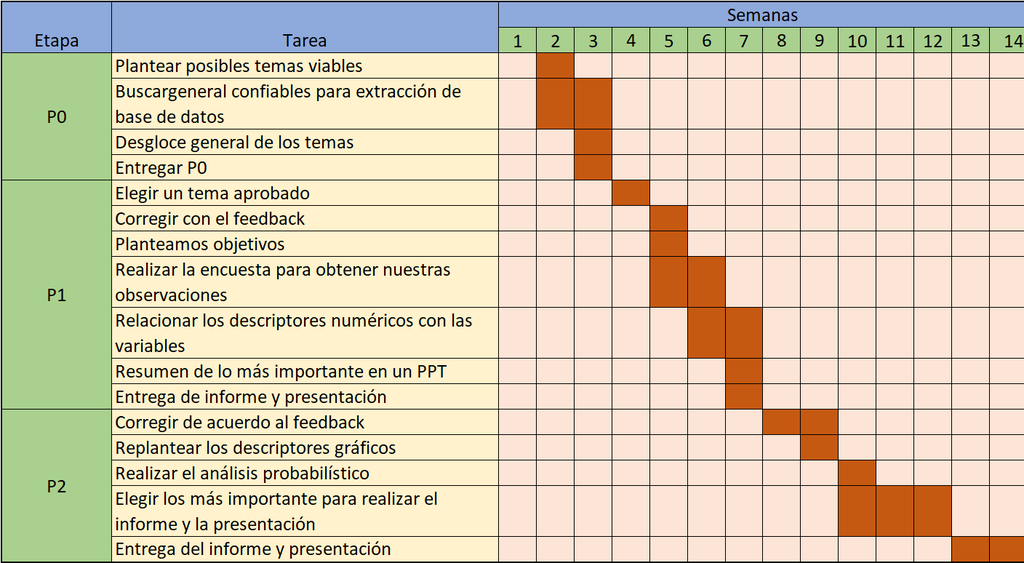

```r
library(readr)
library(tidyr)
```

```r
library(ggplot2)
library(dplyr)
library(modeest)
```

### **Datos**

- **Proceso de recolección de datos**

  Para este trabajo, los datos fueron obtenidos mediante una encuesta creada por el equipo de trabajo y recibió un feedback del profesor a cargo del curso. Esta encuesta contaba con preguntas relacionadas a las variables directamente, y otras que permitían dar contexto a los encuestados. Así, con el fin de motivar a las personas a completar la encuesta, se decidió realizar un sorteo dirigido a todo aquel que lo rellenara y así poder obtener el número de observaciones requeridas.

  Y para lograr un mayor alcance, no nos limitamos a los conocidos y decidimos hacer uso de la red social WhatsApp y Telegram para poder llegar a más personas; asignamos esta tarea a la mayoría de los integrantes del equipo, quien se encargó de enviar las encuestas. Finalmente, es necesario tener en cuenta que esta encuesta tiene un sesgo de confiabilidad, porque asumimos que las personas que completaron la encuesta fueron sinceras y confiables.
- **Población, muestra y muestreo**
  - **Población:**

    Nuestra población de estudio fueron los estudiantes de pregrado de la Universidad de Ingeniería y Tecnología (UTEC) de todas las carreras.
  - **Muestra:**

    nuestro tamaño de muestra es de 220 observaciones.
  - **Muestreo:**

    Tenemos que ser conscientes que nuestra muestra no es representativa, resultando ser esto un muestreo no probabilístico por conveniencia, porque establecimos parámetros específicos para tener una muestra más significativa.

**VARIABLES**

| Variable | Tipo de Variable | Restricciones |
| --- | --- | --- |
| *CÓDIGO:* | categórica ordinal | La cantidad de dígitos mayor a 1 e igual a 9. |
| *EDAD:* | numérica discreta | Es un numero de tipo entero no negativo. |
| *SEXO:* | categórica nominal | Se limita a Masculino, Femenino y Prefiero no decirlo. |
| *CICLO:* | categórica ordinal | Se limita a un rango de 1 hasta 10, siendo cada numero un ciclo es especifico que esta cursando. |
| *CARRERA:* | categórica nominal | Se limita solamente a las carreras brindadas por la UTEC. |
| *PRECIO* | numérica discreta | Es que sea un número entero no negativo. |
| *MODELO* | categórica nominal | Se limita a la elección de todas las marcas existentes y brindadas por nosotros. |
| *ALMACENAMIENTO* | categórica ordinal | Se limita a la elección de la capacidad existentes y ademas que sea de tipo entero. |
| *SISTEMA* | categórica nominal | Se limita a la elección entre Android o iOS u otros. |
| *CÁMARAS* | numérica discreta | Es que sea un número entero no negativo. |
| *CALIDAD* | numérica discreta | Sea un número entero no negativo. |
| *TIEMPO_CARGA* | numérica discreta | Sea convertido a minutos y sea de tipo entero. |
| *DURA_BATERÍA* | numérica discreta | Sea convertido a minutos y sea de tiempo entero. |
| *SATISFACCIÓN* | categórica ordinal | Es que limite a un rango de 1 hasta 5, siendo 1 igual a pésimo y 5 a muy bueno. |

## **2.4 LIMPIEZA DE DATOS**

Uso de las librerías.

- Primero llamaremos a las librerías **“readr” y “dplyr”**

```r
library(readr)

library(dplyr)
```

- Hacemos uso de la librería “readr” con el comando **read_csv** para leer nuestra base de datos y el **col_types** nos ayuda a recategorizar las variables

```r
DFT <- read_csv("Datos_finales_1.csv", col_types = "cncccncccncnnc")
```

- Con los comandos **nrow y ncol** encontramos el número de observaciones (filas) y variables (columnas) de nuestro DataFrame

```r
nrow(DFT)
```

```
## [1] 220
```

```r
ncol(DFT)
```

```
## [1] 14
```

- Al ejecutar la línea de código obtenemos 220 observaciones y 14 variables de nuestro DataFrame (DFT).

Al ver que no se utilizarán todas las variables, haremos uso de la librería “dplyr” con el comando **select** donde crearemos un nuevo DataFrame (DFT2) con nuestras variables que nos permitan poder llegar a hacer el análisis estadístico de acuerdo al objetivo planteado.

```r
DFT2 <- select(DFT, -1, -2 , -4)
```

```r
DFT2
```

| Sexo | Carrera | Precio del Celular aproximado | Modelo del Celular | Almacenamiento del Celular (GB) | Sistema Operativo | Cámaras totales | Calidad de la cámara principal | Tiempo de carga del Celular | Duración de la batería | Satisfacción de tu celular |
| --- | --- | --- | --- | --- | --- | --- | --- | --- | --- | --- |
| Femenino | Ingeniería Ambiental | 3500 | Apple | 256 | IOS ( Apple ) | 3 | 12 | 40 | 840 | 5 |
| Masculino | Ingeniería Industrial | 980 | Motorola | 128 | Android | 4 | 48 | 60 | 270 | 4 |
| Masculino | Ingeniería Mecatrónica | 1000 | Samsung | 64 | Android | 4 | 48 | 60 | 420 | 4 |
| Masculino | Ingeniería Industrial | 1090 | Otros | 128 | Android | 4 | 48 | 90 | 1440 | 5 |
| Femenino | Ingeniería Industrial | 1800 | Samsung | 64 | Android | 4 | 64 | 60 | 1440 | 5 |
| Femenino | Ingeniería Industrial | 800 | Samsung | 64 | Android | 5 | 64 | 120 | 480 | 5 |
| Femenino | Ingeniería Industrial | 1200 | Xiaomi | 128 | Android | 4 | 32 | 60 | 240 | 4 |
| Masculino | Ingeniería Civil | 700 | Xiaomi | 128 | Android | 3 | 48 | 60 | 120 | 4 |
| Masculino | Ingeniería Industrial | 780 | Xiaomi | 128 | Android | 3 | 48 | 120 | 420 | 4 |
| Masculino | Ingeniería Civil | 450 | Huawei | 32 | Android | 2 | 12 | 120 | 90 | 2 |

[output cut: 210 more lines]

- Podemos visualizar que son 11 el número de variables seleccionadas y hemos eliminado a las variables código, ciclo y edad, debido a que estas variables no aportan a nuestro objetivo.

Con la función **names** podemos observar los nombres de las variables del nuevo DataFrame 2.

```r
names(DFT2)
```

```
##  [1] "Sexo"                            "Carrera"
##  [3] "Precio del Celular aproximado"   "Modelo del Celular"
##  [5] "Almacenamiento del Celular (GB)" "Sistema Operativo"
##  [7] "Cámaras totales"                 "Calidad de la cámara principal"
##  [9] "Tiempo de carga del Celular"     "Duración de la batería"
## [11] "Satisfacción de tu celular"
```

- Observamos que algunas variables tienen nombres extensos lo que no nos puede facilitar el trabajo, por ende, se opta a cambiar los nombres y guardarlos en un DataFrame nuevo (DFT3), entonces:

Con el comando **rename**, cambiamos de nombre a las variables que lo requieran a nombres más sencillos y específicos.

```r
DFT3 <- rename(DFT2, Precio =`Precio del Celular aproximado`, Modelo = `Modelo del Celular`, Almacenamiento = `Almacenamiento del Celular (GB)`, Sistema = `Sistema Operativo`, Cámaras = `Cámaras totales`, Calidad_cámara = `Calidad de la cámara principal`, Tiempo_carga = `Tiempo de carga del Celular`, Duración_bateria = `Duración de la batería`, Satisfacción=`Satisfacción de tu celular`)
```

```r
names(DFT3)
```

```
##  [1] "Sexo"             "Carrera"          "Precio"           "Modelo"
##  [5] "Almacenamiento"   "Sistema"          "Cámaras"          "Calidad_cámara"
##  [9] "Tiempo_carga"     "Duración_bateria" "Satisfacción"
```

- Podemos ver que se hizo satisfactoriamente dicho cambio de nombre.

Con **str** verificaremos que nuestras variables estén correctamente categorizadas y sean iguales a la categorización que hicimos al inicio.

```r
str(DFT3)
```

```
## tibble [220 x 11] (S3: tbl_df/tbl/data.frame)
##  $ Sexo            : chr [1:220] "Femenino" "Masculino" "Masculino" "Masculino" ...
##  $ Carrera         : chr [1:220] "Ingeniería Ambiental" "Ingeniería Industrial" "Ingeniería Mecatrónica" "Ingeniería Industrial" ...
##  $ Precio          : num [1:220] 3500 980 1000 1090 1800 800 1200 700 780 450 ...
##  $ Modelo          : chr [1:220] "Apple" "Motorola" "Samsung" "Otros" ...
##  $ Almacenamiento  : chr [1:220] "256" "128" "64" "128" ...
##  $ Sistema         : chr [1:220] "IOS ( Apple )" "Android" "Android" "Android" ...
##  $ Cámaras         : num [1:220] 3 4 4 4 4 5 4 3 3 2 ...
##  $ Calidad_cámara  : chr [1:220] "12" "48" "48" "48" ...
##  $ Tiempo_carga    : num [1:220] 40 60 60 90 60 120 60 60 120 120 ...
##  $ Duración_bateria: num [1:220] 840 270 420 1440 1440 480 240 120 420 90 ...
##  $ Satisfacción    : chr [1:220] "5" "4" "4" "5" ...
```

#### Luego de tener en orden nuestras observaciones y variables:

Verificaremos que no se encuentre ningún dato faltante en nuestro DFT3, para realizar de manera satisfactoria nuestro análisis.

```r
sum(is.na(DFT3))
```

```
## [1] 0
```

- Asimismo, verificaremos que nuestras observaciones o casos estén completos.

```r
sum(complete.cases(DFT3))
```

```
## [1] 220
```

## **ANÁLISIS EXPLORATORIO POR VARIABLE**

- **Variables Catégoricas**

Con el comando **table** verificaremos que en nuestra variable **Sexo** no presenten anomalías y con un barplot ver la proporción del género de los estudiantes.

```r
table(DFT3$Sexo)
```

```
##
##            Femenino           Masculino Prefiero no decirlo
##                 101                 117                   2
```

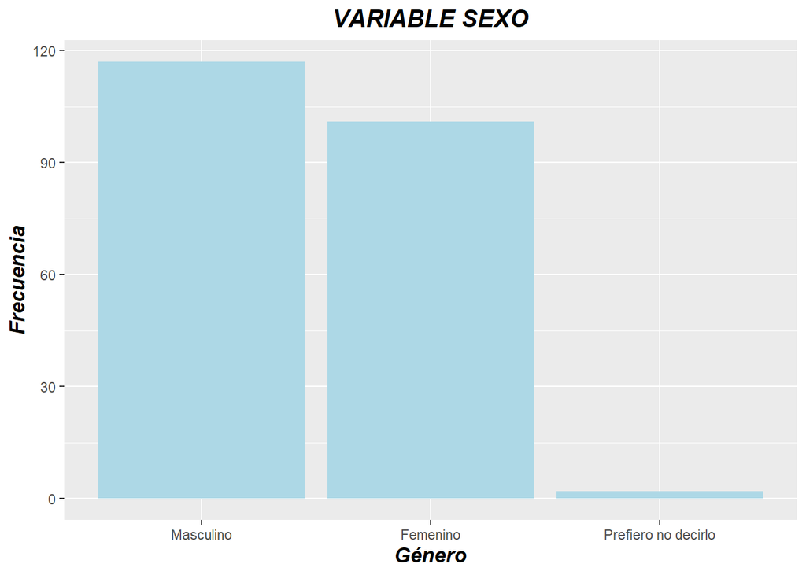

```r
ggplot(DFT3) +
  aes(x = reorder(Sexo, Sexo, function(x)-length(x))) +
  geom_bar(fill = "light blue") +
  labs(
    x = "Género",
    y = "Frecuencia",
    title = "VARIABLE SEXO"
  ) +
  theme_gray() +
  theme(
    plot.title = element_text(size = 15L,
    face = "bold.italic",
    hjust = 0.5),
    axis.title.y = element_text(size = 13L,
    face = "bold.italic"),
    axis.title.x = element_text(size = 13L,
    face = "bold.italic")
  )
```

Asimismo, para nuestra variable **Carrera** solo serán contables las carreras que brinda la Universidad que en total son 12 carreras, en este caso la encuesta se llegó a llenar solo por estudiantes de 10 de las 12 carreras.

```r
table(DFT3$Carrera)
```

```
##
##               Bioingeniera Ciencias de la Computación
##                         16                         25
##       Ingeniería Ambiental           Ingeniería Civil
##                         16                         48
##   Ingeniería de la Energía     Ingeniería Electrónica
##                          5                          5
##      Ingeniería Industrial        Ingeniería Mecánica
##                         63                         11
##     Ingeniería Mecatrónica         Ingeniería Química
##                         21                         10
```

```r
DFT3
```

| Sexo | Carrera | Precio | Modelo | Almacenamiento | Sistema | Cámaras | Calidad_cámara | Tiempo_carga | Duración_bateria | Satisfacción |
| --- | --- | --- | --- | --- | --- | --- | --- | --- | --- | --- |
| Femenino | Ingeniería Ambiental | 3500 | Apple | 256 | IOS ( Apple ) | 3 | 12 | 40 | 840 | 5 |
| Masculino | Ingeniería Industrial | 980 | Motorola | 128 | Android | 4 | 48 | 60 | 270 | 4 |
| Masculino | Ingeniería Mecatrónica | 1000 | Samsung | 64 | Android | 4 | 48 | 60 | 420 | 4 |
| Masculino | Ingeniería Industrial | 1090 | Otros | 128 | Android | 4 | 48 | 90 | 1440 | 5 |
| Femenino | Ingeniería Industrial | 1800 | Samsung | 64 | Android | 4 | 64 | 60 | 1440 | 5 |
| Femenino | Ingeniería Industrial | 800 | Samsung | 64 | Android | 5 | 64 | 120 | 480 | 5 |
| Femenino | Ingeniería Industrial | 1200 | Xiaomi | 128 | Android | 4 | 32 | 60 | 240 | 4 |
| Masculino | Ingeniería Civil | 700 | Xiaomi | 128 | Android | 3 | 48 | 60 | 120 | 4 |
| Masculino | Ingeniería Industrial | 780 | Xiaomi | 128 | Android | 3 | 48 | 120 | 420 | 4 |
| Masculino | Ingeniería Civil | 450 | Huawei | 32 | Android | 2 | 12 | 120 | 90 | 2 |

[output cut: 210 more lines]

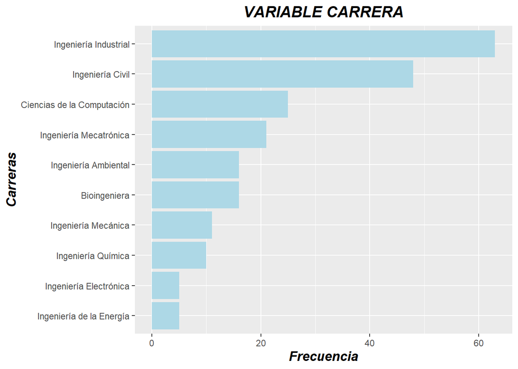

```r
ggplot(DFT3) +
  aes(x = reorder(Carrera, Carrera, function(x)+length(x))) +
  geom_bar(fill = "light blue") +
  labs(
    x = "Carreras",
    y = "Frecuencia",
    title = "VARIABLE CARRERA"
  ) +
  coord_flip() +
  theme_gray() +
  theme(
    plot.title = element_text(size = 15L,
    face = "bold.italic",
    hjust = 0.5),
    axis.title.y = element_text(size = 13L,
    face = "bold.italic"),
    axis.title.x = element_text(size = 13L,
    face = "bold.italic")
  )
```

- OBSERVACIÓN
- No se encontraron alumnos de las carreras de: Administración y Negocios Digitales y Ciencia de Datos, que llenaron la encuesta realizada, por tanto, se tomará encuesta solo a los alumnos de las carreras que llenaron esta encuesta.

Para nuestra variable **modelo**, verificaremos que se encuentren marcas que en realidad existan y no haya problemas en la escritura. También se hace un barplot para ver que modelo de celular es más adquirido por los estudiantes.

```r
table(DFT3$Modelo)
```

```
##
##    Apple   Huawei       LG Motorola    Otros  Samsung     Sony   Xiaomi
##       20       38        1       15        4       75        1       61
##      ZTE
##        5
```

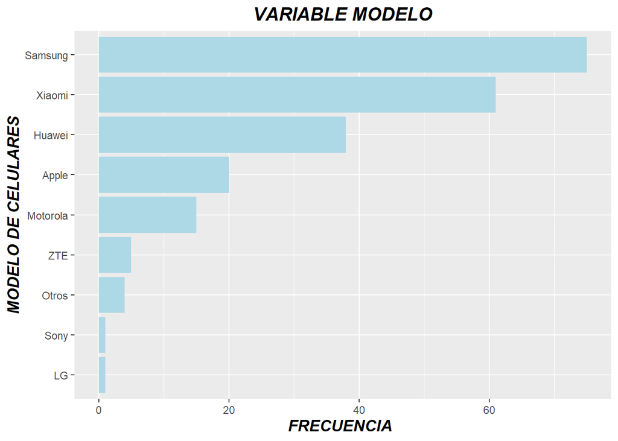

```r
ggplot(DFT3) +
  aes(x =reorder(Modelo,Modelo,function(x)+length(x))) +
  geom_bar(fill = "light blue") +
  labs(
    x = "MODELO DE CELULARES",
    y = "FRECUENCIA ",
    title = "VARIABLE MODELO"
  ) +
  coord_flip() +
  theme_gray() +
  theme(
    plot.title = element_text(size = 15L,
    face = "bold.italic",
    hjust = 0.5),
    axis.title.y = element_text(size = 13L,
    face = "bold.italic"),
    axis.title.x = element_text(size = 13L,
    face = "bold.italic")
  )
```

- Las marcas encontradas son existentes y están correctamente escritas y podemos ver en el barplot que el modelo Samsung es el más adquirido por los estudiantes de la UTEC.

Para nuestra variable **SISTEMA**

```r
table(DFT3$Sistema)
```

```
##
##       Android IOS ( Apple )
##           200            20
```

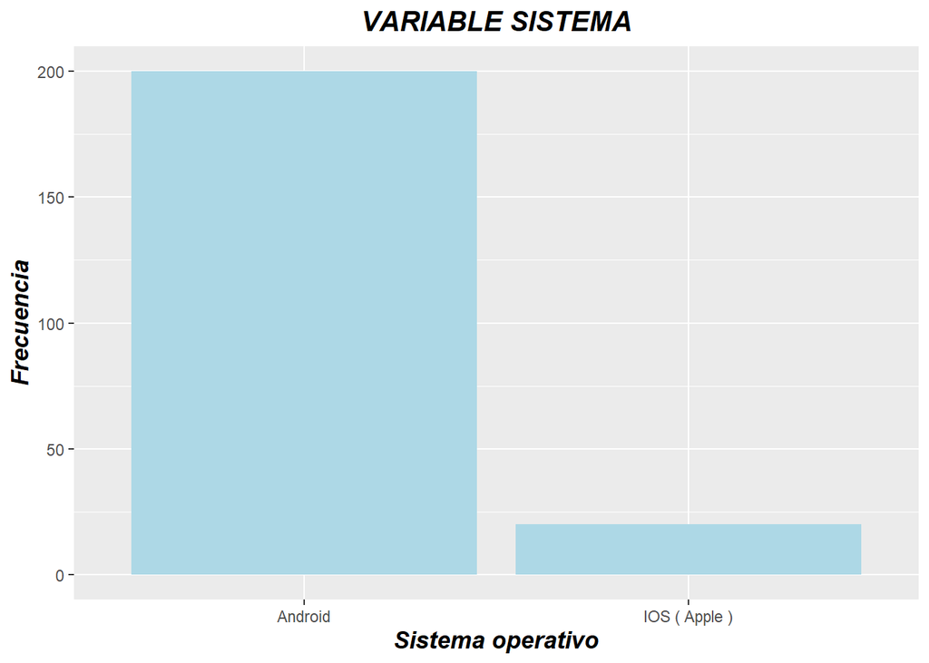

```r
ggplot(DFT3) +
  aes(x = Sistema) +
  geom_bar(fill = "light blue") +
  labs(
    x = "Sistema operativo",
    y = "Frecuencia",
    title = "VARIABLE SISTEMA"
  ) +
  theme_gray() +
  theme(
    plot.title = element_text(size = 15L,
    face = "bold.italic",
    hjust = 0.5),
    axis.title.y = element_text(size = 13L,
    face = "bold.italic"),
    axis.title.x = element_text(size = 13L,
    face = "bold.italic")
  )
```

Por último, para la variable **SATISFACCIÓN** utilizamos el comando **table**, lo que nos permite ver cuantos estudiantes estan satisfechos con sus celulares en una categoria de 1 a 5, donde 1 es malo y 5 es muy bueno.

```r
table(DFT3$Satisfacción)
```

```
##
##  1  2  3  4  5
##  1  2 35 98 84
```

- OBSERVACIÓN
- Si se encuentran dentro de la escala determinada en la encuesta por ende no hay anomalía.
- **Variables Numéricas**

Para nuestra variable **Calidad_cámara**, verificaremos que no se encuentre algún dato atípico incongruente

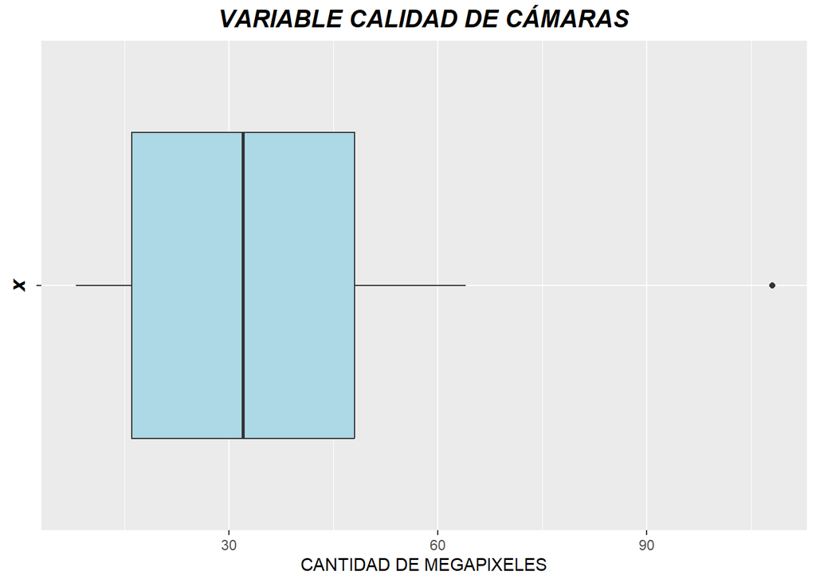

```r
ggplot(DFT3) +
  aes(x = "", y = as.numeric(Calidad_cámara)) +
  geom_boxplot(fill = "light blue") +
  labs(y = "CANTIDAD DE MEGAPIXELES", title = "VARIABLE CALIDAD DE CÁMARAS") +
  coord_flip() +
  theme_gray() +
  theme(
    plot.title = element_text(size = 15L,
    face = "bold.italic",
    hjust = 0.5),
    axis.title.y = element_text(size = 13L,
    face = "bold.italic")
  )
```

- OBSERVACIÓN
- Al hacer una investigación llegamos a la conclusión de que si existe un celular con una calidad de cámara posterior “108 MP” y se trata de un GALAXY S22 ULTRA, por lo tanto no existe anomalía.También encontramos el maximo y minimo valor de la calidad de camara.

Para nuestra variable “**Cámaras**”, eliminaremos aquellos modelos de celulares que no cuenten con ninguna cámara o mayor a 7 por ser algo ilógico

```r
DFT3[which(DFT3$Cámaras<0), 7] <- NA
DFT3[which(DFT3$Cámaras>6), 7] <- NA
```

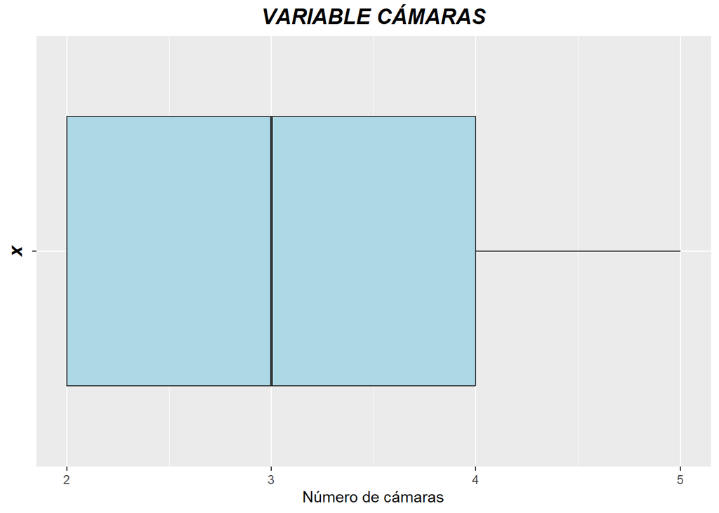

```r
ggplot(DFT3) +
  aes(x = "", y = Cámaras) +
  geom_boxplot(fill = "light blue") +
  labs(y = "Número de cámaras", title = "VARIABLE CÁMARAS") +
  coord_flip() +
  theme_gray() +
  theme(
    plot.title = element_text(size = 15L,
    face = "bold.italic",
    hjust = 0.5),
    axis.title.y = element_text(size = 13L,
    face = "bold.italic")
  )
```

```r
round(mean(DFT3$Cámaras), 2)
```

```
## [1] 3.39
```

- visulizamos que la mediana de la cantidad de camara es 3 y su promedio esta entre 3 y 4 camaras.

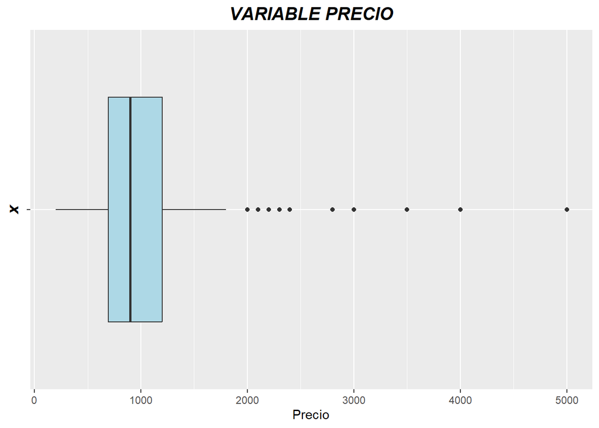

```r
ggplot(DFT3) +
  aes(x = "", y = Precio) +
  geom_boxplot(fill = "light blue") +
  labs(y = "Precio", title = "VARIABLE PRECIO") +
  coord_flip() +
  theme_gray() +
  theme(
    plot.title = element_text(size = 15L,
    face = "bold.italic",
    hjust = 0.5),
    axis.title.y = element_text(size = 13L,
    face = "bold.italic")
  )
```

```r
which.max(DFT3$Precio)
```

```
## [1] 51
```

Para nuestra variable **almacenamiento** primero convertimos a numerica, y encontramos los datos atípicos.

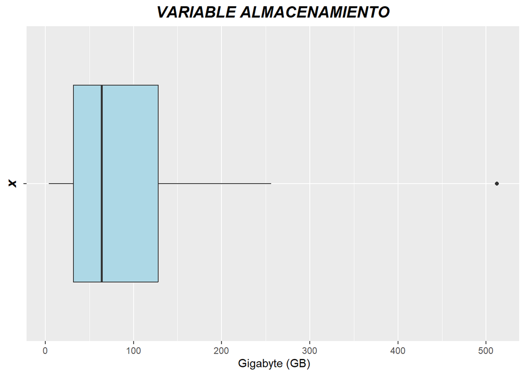

```r
ggplot(DFT3) +
  aes(x = "", y = as.numeric(Almacenamiento)) +
  geom_boxplot(fill = "light blue") +
  labs(y = " Gigabyte (GB)", title = "VARIABLE ALMACENAMIENTO") +
  coord_flip() +
  theme_gray() +
  theme(
    plot.title = element_text(size = 15L,
    face = "bold.italic",
    hjust = 0.5),
    axis.title.y = element_text(size = 13L,
    face = "bold.italic")
  )
```

- OBSERVACIÓN
- Encontramos un celular con almacenamiento de “512 GB”, lo cual no es algo descabellado, se trata de un IPHONE 13 PRO MAX con memoria expandible.

## **3. ANALISIS DESCRIPTIVO**

Teniendo anteriormente las variables ya seleccionadas que son 11, las analizamos para relacionamos entre ellas.

## **Descriptores númericos y graficos**

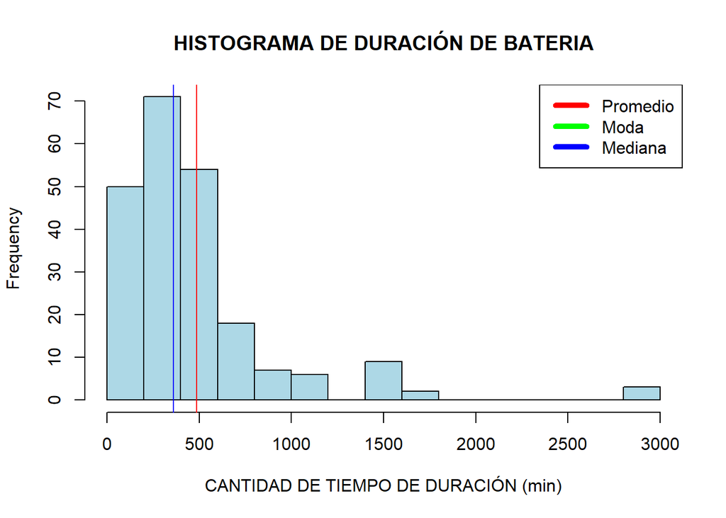

```r
hist(DFT3$Duración_bateria, xlab="CANTIDAD DE TIEMPO DE DURACIÓN (min)", main="HISTOGRAMA DE DURACIÓN DE BATERIA",breaks=15,col="light blue")
abline(v=mean(DFT3$Duración_bateria),col="red")
abline(v=mfv(DFT3$Duración_bateria),col="green")
abline(v=median(DFT3$Duración_bateria),col="blue")
legend("topright",c("Promedio","Moda","Mediana"),col=c("red","green","blue"),lty=1:1,lwd = 5)
```

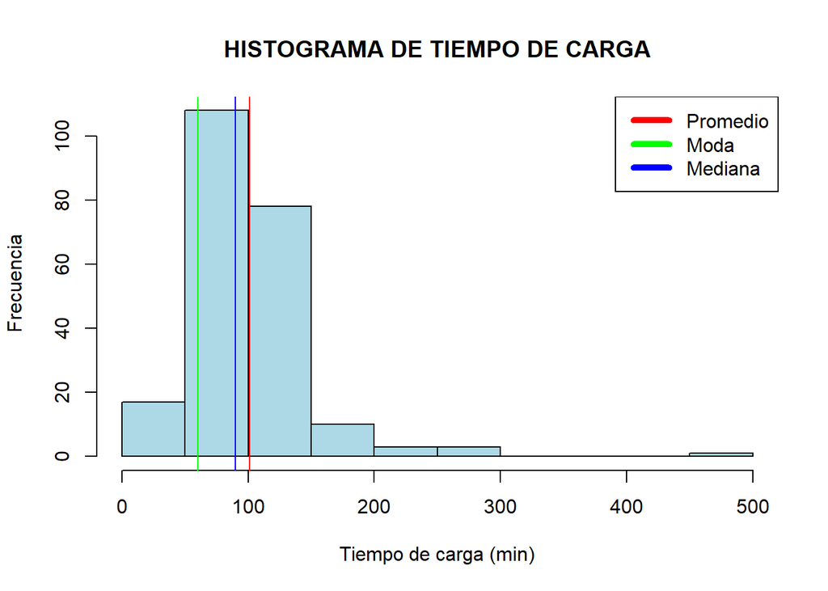

```r
hist(DFT3$Tiempo_carga,breaks=15,main="HISTOGRAMA DE TIEMPO DE CARGA",xlab="Tiempo de carga (min)",ylab="Frecuencia", col = "light blue")
abline(v=mean(DFT3$Tiempo_carga),col="red")
abline(v=mfv(DFT3$Tiempo_carga),col="green")
abline(v=median(DFT3$Tiempo_carga),col="blue")
legend("topright",c("Promedio","Moda","Mediana"),col=c("red","green","blue"),lty=1:1,lwd = 5)
```

- Según el histograma observamos que el tiempo promedio de duración de batería es 485 minutos lo que es equivalente a 8 horas y 5 minutos.
- Según el histograma realizado observamos que la cantidad de tiempo de carga tiene un promedio de 101 minutos lo que es equivalente a 1 hora y 41 minutos.
- Al realizar una comparación entre ambas gráficas se puede inferir que para un tiempo promedio de carga de 1 hora y 41 minutos y la batería tiene una duración promedio de 8 horas y 5 minutos.

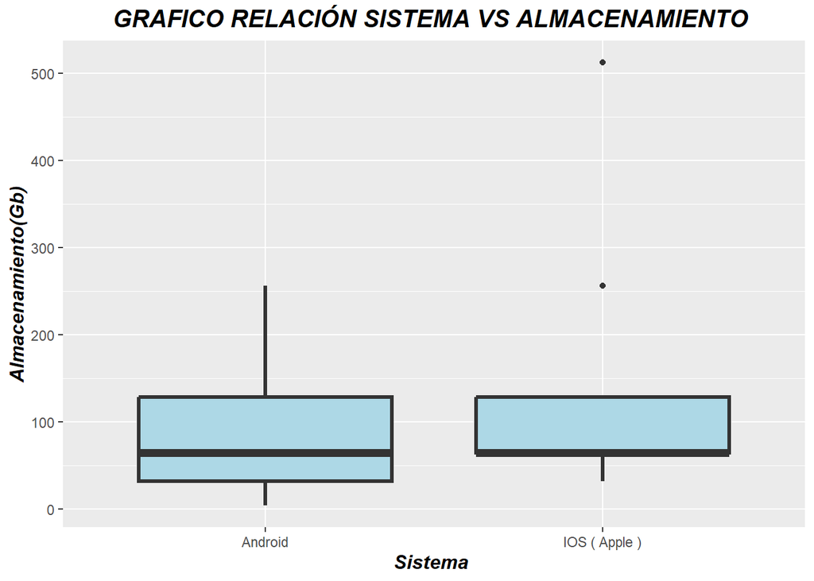

```r
DFT3 %>%
 filter(!(Sistema %in% "Otros")) %>%
 ggplot() +
  aes(x = Sistema, y = as.numeric(Almacenamiento))+
  geom_boxplot(size = 1.2, fill="light blue") +
  labs(
    x = "Sistema ",
    y = "Almacenamiento(Gb)",
    title = "GRAFICO RELACIÓN SISTEMA VS ALMACENAMIENTO "
  ) +
  theme_minimal() +
  theme_gray() +
  theme(
    plot.title = element_text(size = 15L,
    face = "bold.italic",
    hjust = 0.5),
    axis.title.y = element_text(size = 12L,
    face = "bold.italic"),
    axis.title.x = element_text(size = 12L,
    face = "bold.italic")
  )
```

La gráfica de Boxplot nos indica los datos atípicos que tenemos en la variable almacenamiento según el Sistema, exactamente en el sistema operativo iOS, también notamos que la media en ambos sistemas estan en un mismo rango de <50,100>, y ambos tienen un mediana semejante.

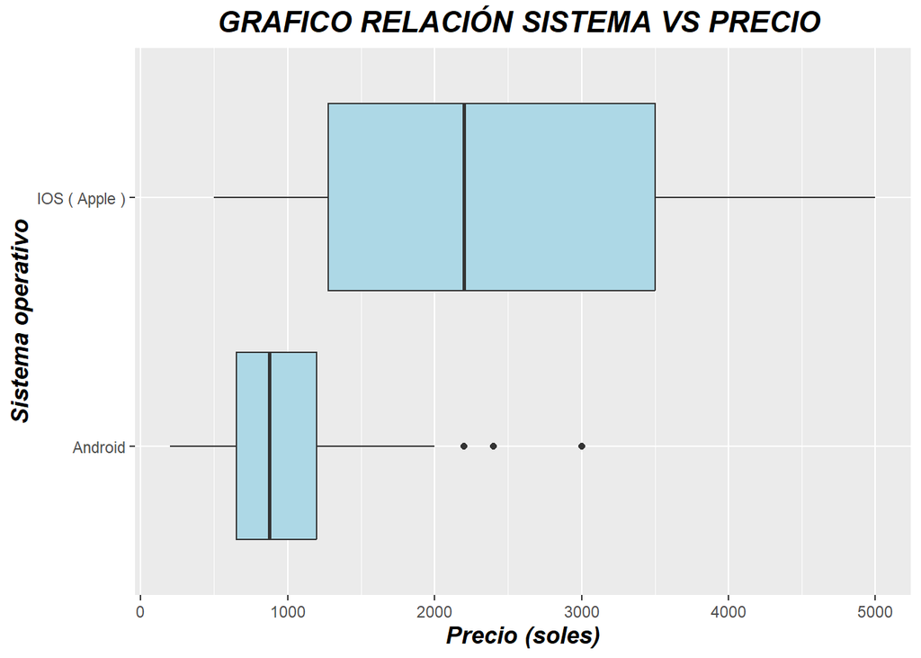

```r
  DFT3 %>%
 filter(!(Sistema %in% "Otros")) %>%
 ggplot() +
  aes(x = Sistema, y = Precio) +
  geom_boxplot(fill = "light blue") +
  labs(
    x = "Sistema operativo",
    y = "Precio (soles)",
    title = "GRAFICO RELACIÓN SISTEMA VS PRECIO "
  ) +
  coord_flip() +
  theme_gray() +
  theme(
    plot.title = element_text(size = 16L,
    face = "bold.italic",
    hjust = 0.5),
    axis.title.y = element_text(size = 13L,
    face = "bold.italic"),
    axis.title.x = element_text(size = 13L,
    face = "bold.italic")
  )
```

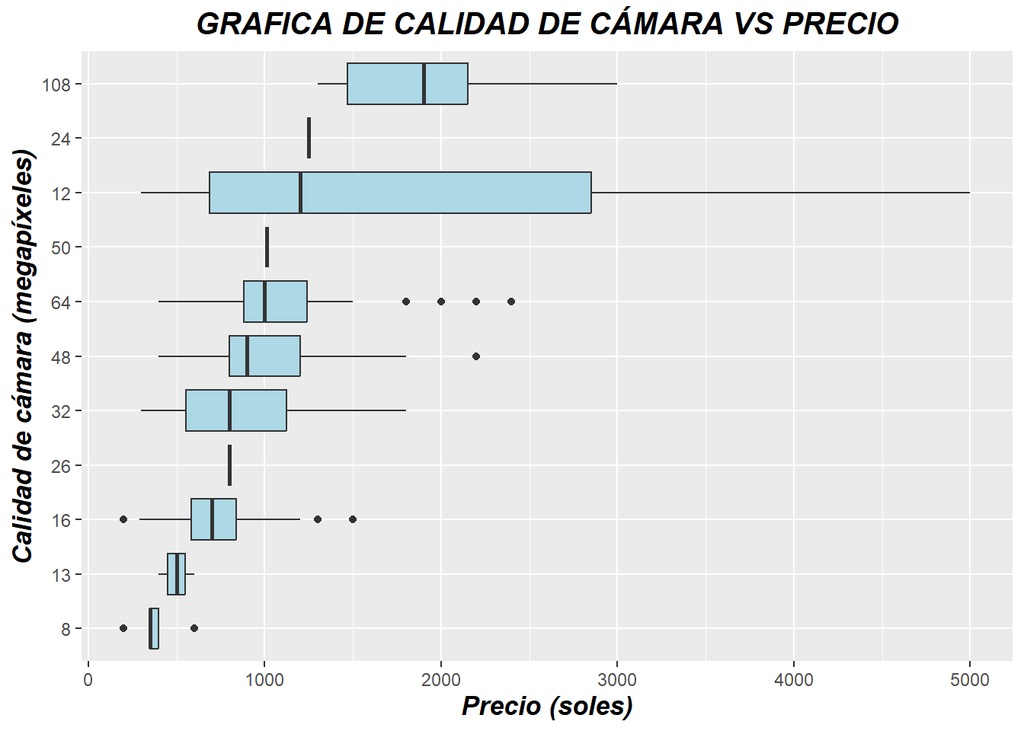

```r
ggplot(DFT3) +
  aes(x = reorder(Calidad_cámara,Precio,median), y = Precio) +
  geom_boxplot(fill = "light blue") +
  labs(
    x = "Calidad de cámara (megapíxeles)",
    y = "Precio (soles)",
    title = "GRAFICA DE CALIDAD DE CÁMARA VS PRECIO"
  ) +
  coord_flip() +
  theme_gray() +
  theme(
    plot.title = element_text(size = 15L,
    face = "bold.italic",
    hjust = 0.5),
    axis.title.y = element_text(size = 13L,
    face = "bold.italic"),
    axis.title.x = element_text(size = 13L,
    face = "bold.italic")
  )
```

Esta gráfica de boxplot nos indica la relación que existe entre la calidad de cámara y el precio, se puede observar como los celulares con una calidad de cámara de 108 Mpx son más costosos que la calidad de 8 Mpx, el cual notoriamente es menos costoso.

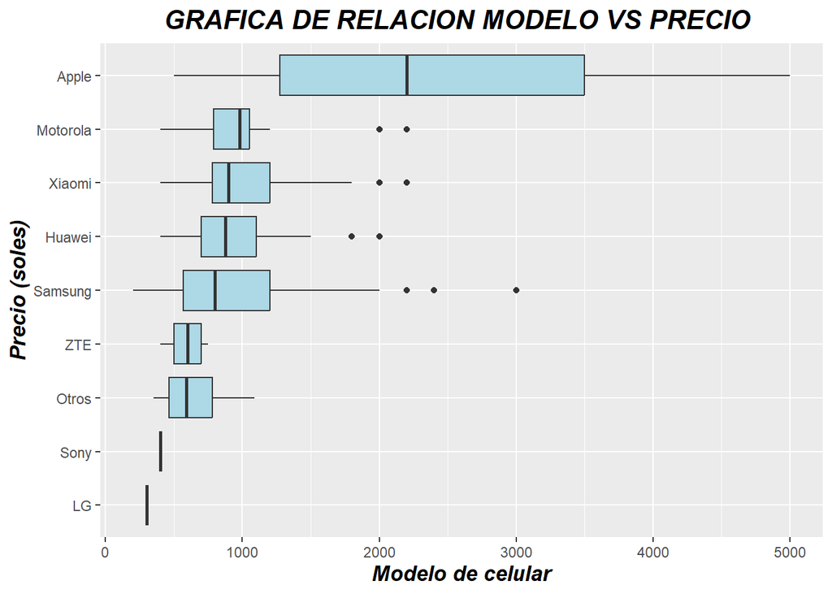

```r
ggplot(DFT3) +
  aes(x = reorder(Modelo,Precio,median), y = Precio) +
  geom_boxplot(fill = "light blue") +
  labs(
    x = "Precio (soles)",
    y = "Modelo de celular",
    title = "GRAFICA DE RELACION MODELO VS PRECIO "
  ) +
  coord_flip() +
  theme_gray() +
  theme(
    plot.title = element_text(size = 16L,
    face = "bold.italic",
    hjust = 0.5),
    axis.title.y = element_text(size = 13L,
    face = "bold.italic"),
    axis.title.x = element_text(size = 13L,
    face = "bold.italic")
  )
```

En la presente gráfica de boxplot se usaron las variables precio y modelo para analizar cual de todos los modelos es más costoso y cual es el más accesible o cómodo para las personas.Asimismo se observa la mediana, el rango intercuartil y la dispersión que existe en cada modelo.

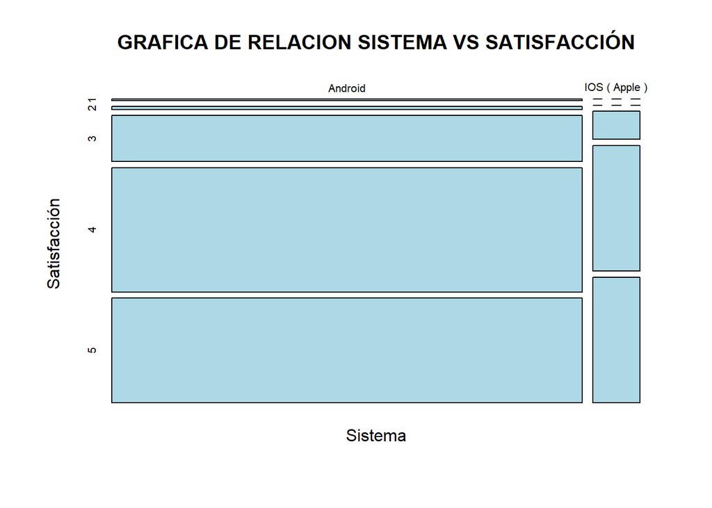

```r
mosaicplot(DFT3$Sistema~DFT3$Satisfacción, xlab = "Sistema", ylab = "Satisfacción", main = "GRAFICA DE RELACION SISTEMA VS SATISFACCIÓN", col = "light blue")
```

Primero se categorizó la variable satisfacción:

| *satisfacción* | *significado* |
| --- | --- |
| *1* | *muy malo* |
| *2* | *malo* |
| *3* | *mas o menos* |
| *4* | *bien* |
| *5* | *muy bien* |

## **Análisis probabilístico**

En esta parte del estudio, se desarrollará el análisis probabilístico aplicado en nuestra base de datos. El objetivo es encontrar probabilidades que nos ayuden a conocer eventos importantes para el desarrollo de nuestra investigación, además de calcular sus probabilidades de ocurrencia según lo requieran.

En primer lugar definimos los axiomas y las propiedades que nos ayudaran a encontrar la probabilidad de los eventos.

- Dados $(Ω, F, P)$, la función de probabilidad $P : Ω → [0, 1]$ asigna valores $P(E)$ a cada evento $E ∈ F$, satisface los siguientes axiomas:
- Axima 1 (A1): $P(E) ≥ 0, ∀E ∈ F$
- Axima 2 (A2): $P(Ω) = 1$
- Axioma 3 (A3): Si $Ei$ es un evento para todo $i ∈ N$ tal que $Ei ∩ Ej = ∅, ∀ i ≠ j$ entonces

$∑ P(Ei)$ de 1 hata el infinito.

**Propiedades de $P$ (consecuencias de los axiomas):**

- Para $E, A, B ∈ F:$
- 1. $P(∅) = 0$
- 2. $P(Ac) = 1 − P(A) Ac = Ω ∖ A$
- 3. $P(A) ≤ 1$
- 4. $P(A ∪ B)= P(A) + P(B) − P(A ∩ B)$, entre otras.

Un pequeño ejemplo de probabilidades de dos conjuntos disjuntos.

```r
table(DFT3$Sistema)
```

```
##
##       Android IOS ( Apple )
##           200            20
```

A–> sistema operador Android

B–> Sistema operador iOS

sean A Y B dos eventos disjuntos con P(A) = 0.90 y P(B)= 0.10. ¿Cuál es la probabilidad de que B ocurra pero A no?

- Como son eventos disjuntos entonces uno no depende de otro, por ende la probabilidad de que ocurra B pero A no es igual a 0.1.

## **Variables aleatorias y distribuciones**

Como **primer punto**, queremos conocer a los estudiantes que tienen un sistema operdor Android.

Analizando la variable Sistema observamos que es una variable dicotómica, es decir que toma solo dos valores posibles:

(1): Si tiene un sistema operador Android. (Éxito)

(2): No cuenta con operdor Android. (Fracaso)

## **Modelo de problema Bernuolli**

Por tanto podemos decir que esta variable podría seguir un proceso de Bernoulli, debido a que cumple que solo exista dos resultados posibles, los ensayos son independientes, es decir, el resultado de cualquier ensayo es independiente del resultado de cualquier otro ensayo, y la probabilidad de exito p es constante de ensayo en ensayo.

Ahora, calculamos el valor de p con:

- X: El estudiante cuenta con un sistema operativo Android.

Donde X sigue una distribución Bernoulli, es decir:

$X∼Bernoulli(p)$

Calculando el valor del parámetro p:

```r
round(table(DFT3$Sistema)/length(DFT3$Sistema),2)
```

```
##
##       Android IOS ( Apple )
##          0.91          0.09
```

Podemos decir que el parámetro obtiene un valor de 0.91.

Ahora, como sabemos, a partir de una distribución Bernoulli podemos hacernos preguntas sobre el número total de éxitos obtenidos en un proceso de n ensayos Bernoulli.

Como **segundo punto**, queremos analizar la cantidad de estudiantes que cuentan con un celular Modelo Sansung, para lo cual tenemos una referencia de cada modelo de celular, con sus respectivos porcentajes en el mercado.

- Según Alferez V., & Calcina H, (2020) en la actualidad en el mercado de teléfonos móviles está conformado por cinco marcas que representan el 66% de ventas a nivel mundial. Estas son: Samsung, Huawei, Apple, Xiaomi, Oppo con 22%, 16%, 10%, 9% y 9%. Por otro lado, en el mercado peruano, según un estudio de la Cámara de Comercio de Lima, Samsung, Huawei, Apple y LG concentran el 76% del mercado de telefonía móvil. De acuerdo a ello nosotros queremos comprobar en la encuesta realizada a los estudiantes de UTEC si el modelo de celular se asemeja a lo encontrado en la fuente, pero con la base de datos que recolectemos.

Para ello podemos ver la cantidad de estudiantes que tienen sus celulares con sus repectivos modelos.

```r
table(DFT3$Modelo)
```

```
##
##    Apple   Huawei       LG Motorola    Otros  Samsung     Sony   Xiaomi
##       20       38        1       15        4       75        1       61
##      ZTE
##        5
```

Obteniendo el porcentaje de estudiantes tienen modelo de celulares Sansung para nuestro problema modelo.

```r
r <- function(x){
  return(round(x,digits = 2))
}
```

```r
a <- DFT3 %>% filter(DFT3$Modelo== "Samsung" )
count(a)
```

| n |
| --- |
| 75 |

```r
r((75/220)*100)
```

```
## [1] 34.09
```

## **Modelo de problema binomial**

En estudio realizado en las preferencias de modelos de celulares, la prabilidad de obtener a una persona con un modelo de celular Samsung es del 34 %. Calcule la probabilidad de que en una muestra de 30 estudiantes haya menos o igual que 3 estudiantes con un modelo de celular Samsung.

X = Variable aleatoria –> Numero de estudiantes con modelo de celular Samsung

r = número de exitos –> 3 estudiantes

$X∼Binomial(p)$

sabiendo lo anterior podemos decir que se trata de una distribucion binomial, entonces calculamos lo siguente:

```r
pbinom(3,30,0.34)
```

```
## [1] 0.00264996
```

## **Gráfica binomial**

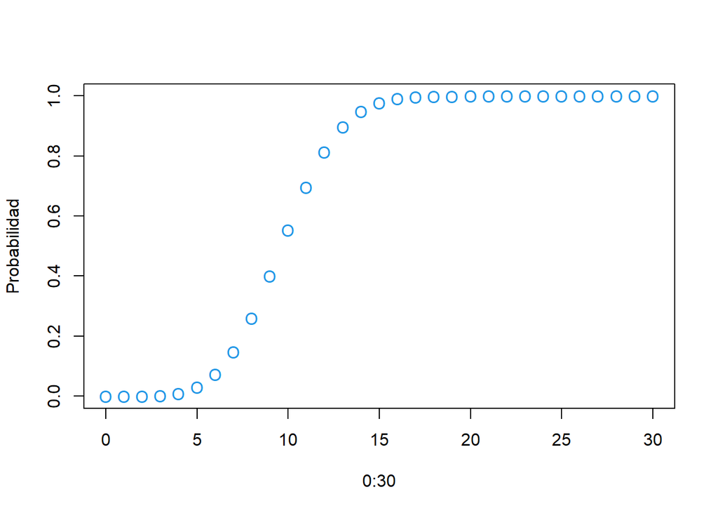

```r
plot(0:30,pbinom(0:30,30,0.34),xlab="0:30",ylab="Probabilidad",col="68",pch="O")
```

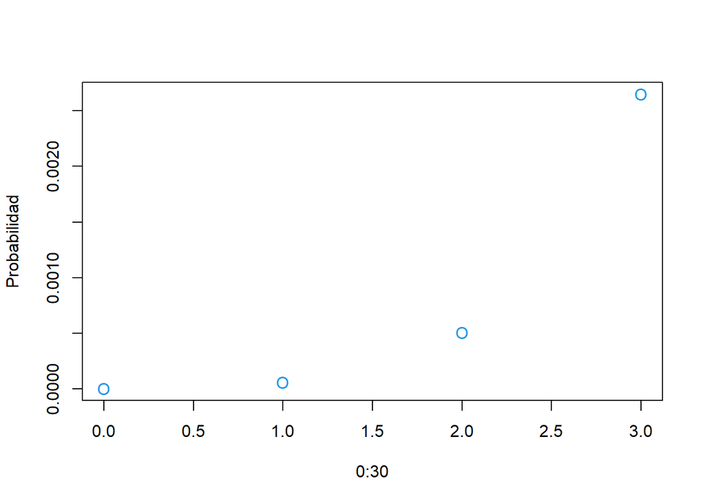

```r
plot(0:3,pbinom(0:3,30,0.34),xlab="0:30",ylab="Probabilidad",col="68",pch="O")
```

## **Grafica de la probabilidad de la distribución binomial**

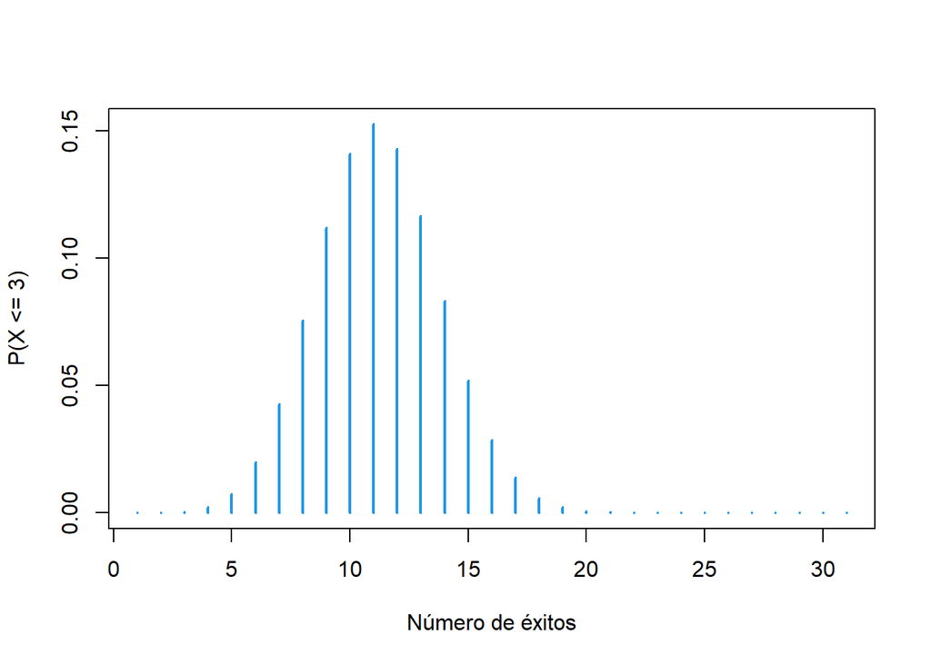

```r
plot(dbinom(0:30, size = 30, prob = 0.34), type = "h",col = "68", lwd = 2,
          ylab = "P(X <= 3)", xlab = "Número de éxitos")
```

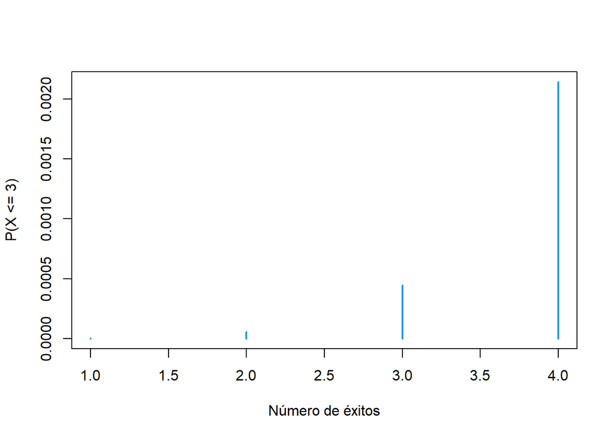

```r
plot(dbinom(0:3, size = 30, prob = 0.34), type = "h",col = "68", lwd = 2,
          ylab = "P(X <= 3)", xlab = "Número de éxitos")
```

Como podemos ver en las graficas anteriores, se muestra la probabilidad de la distribucion binomial, tambien la probabilidad de que haya meno o igual a 3 estudiantes con un modelo de celular Sansung es de 0,0026.